# Greatest Speeches in History

[figure not shown]

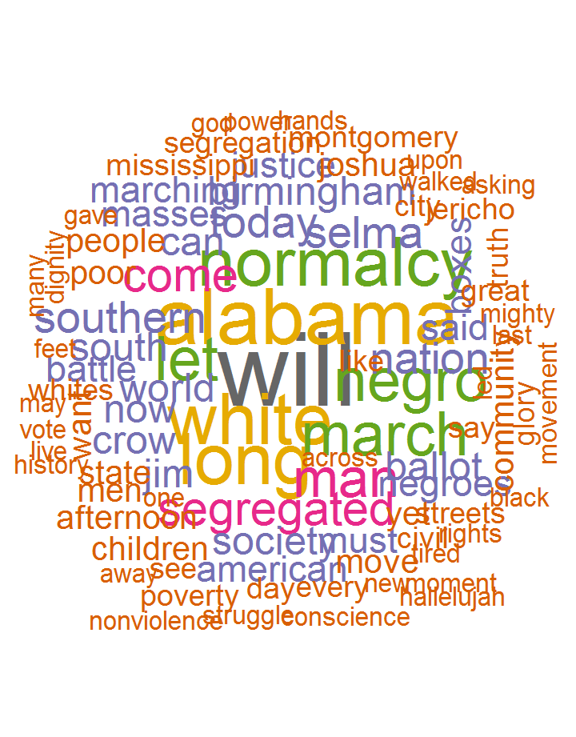

[figure not shown]

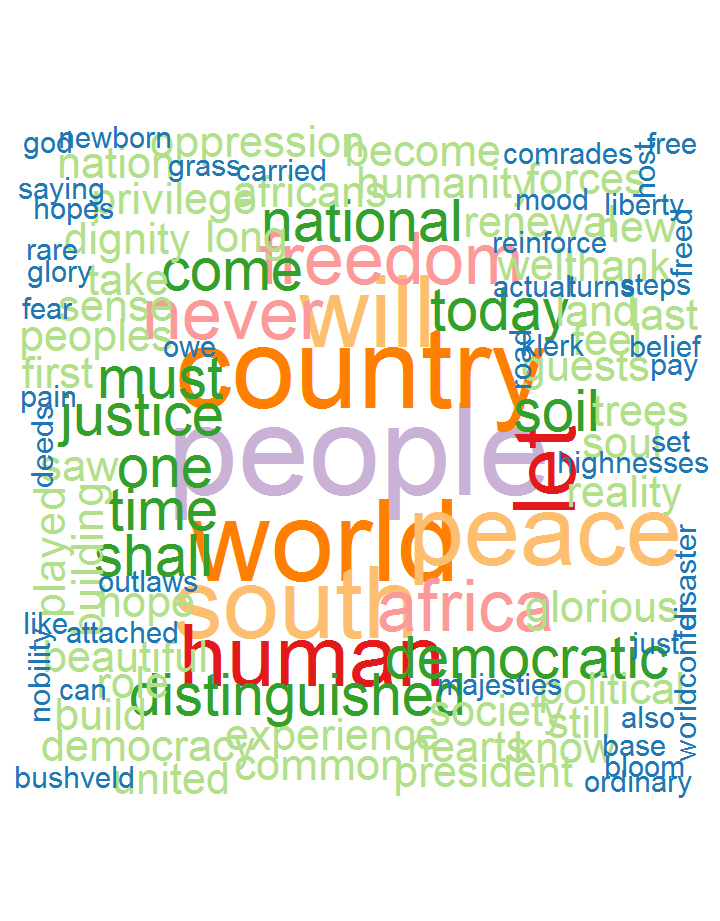

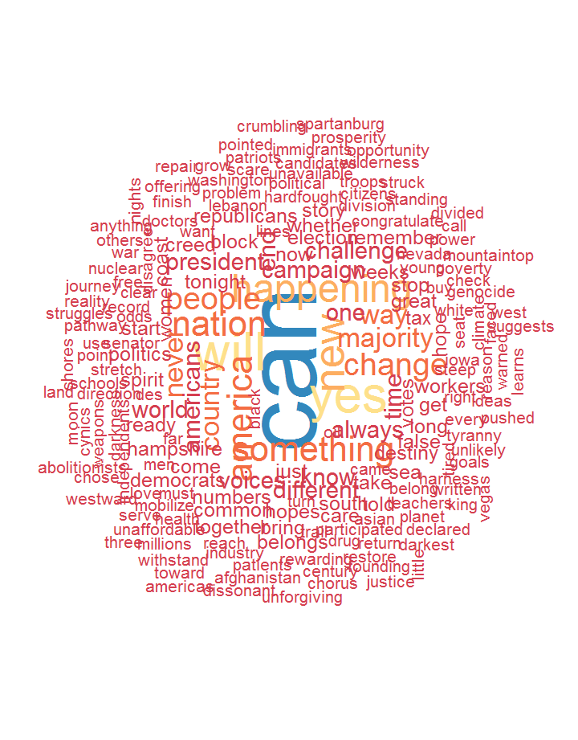

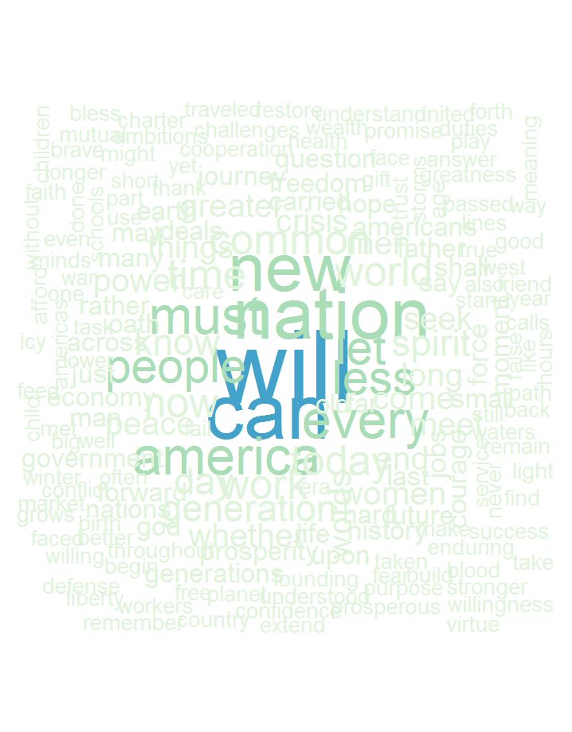

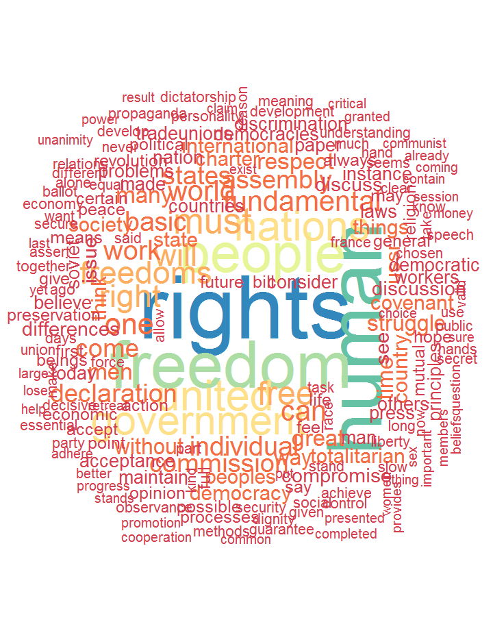

# Martin Luther King, Jr

**“I have a dream” - Martin Luther King, Jr.**

Delivered by Martin Luther King, Jr. on 28 August 1963, at the Lincoln Memorial, Washington D.C.

In his most famous speech, Martin Luther King, Jr stood on the steps of the Lincoln Memorial to deliver the speech before a crowd of more than 250,000 people.

**“Our God Is Marching On” - Martin Luther King, Jr.**

“Our God Is Marching On!” Reverend Martin Luther King, Jr. Speech, March 25, 1965

### “I have a dream” - Martin Luther King, Jr.

[figure not shown]

### “Our God Is Marching On” - Martin Luther King, Jr.

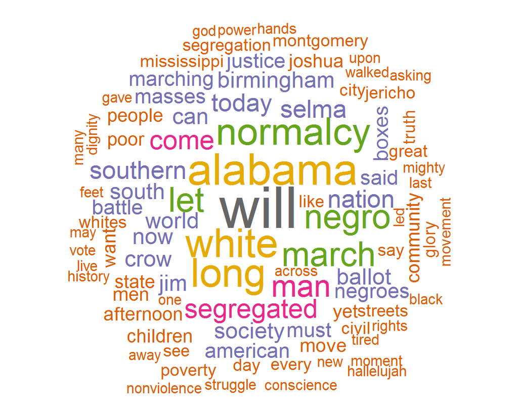

# Nelson Mandela

**“I am prepared to die” - Nelson Mandela**

Nelson Mandela made this speech in court in 1964, just before he was sent to prison.

“I am prepared to die” - Nelson Mandela’s speech from the dock in the Rivonia Trial in which he said he was prepared to die for a democratic, non-racial South Africa.

**“A rainbow nation” - Nelson Mandela**

Inaugural Speech, Pretoria - Nelson Mandela - 10 May 1994

Nelson Mandela made this speech when he was made President of South Africa on 10 May 1994.

### “I am prepared to die” - Nelson Mandela

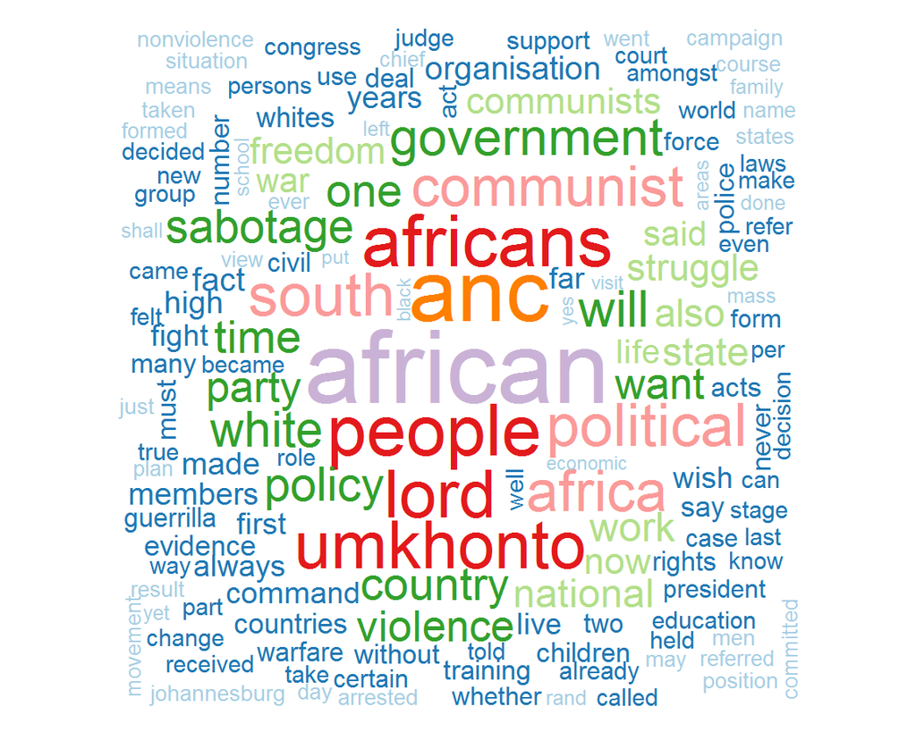

### “A rainbow nation” - Nelson Mandela

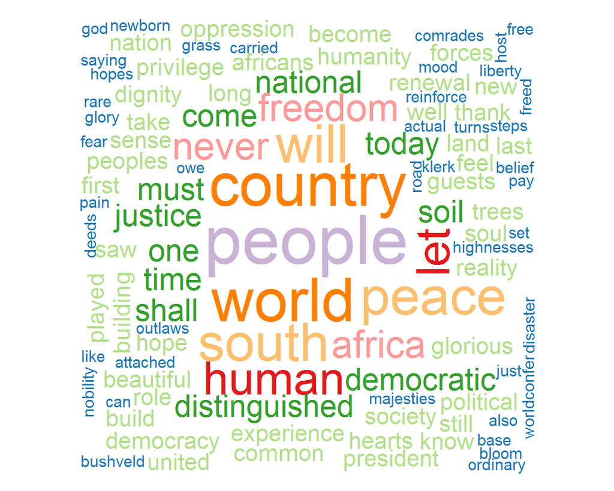

# Barack Obama

**“Yes We Can” - Barack Obama**

Senator Barack Obama’s speech to supporters after the New Hampshire primary. 10th January 2008

**Inaugural Address - Barack Obama**

Obama Inaugural Address - 20th January 2009

### “Yes We Can” - Barack Obama

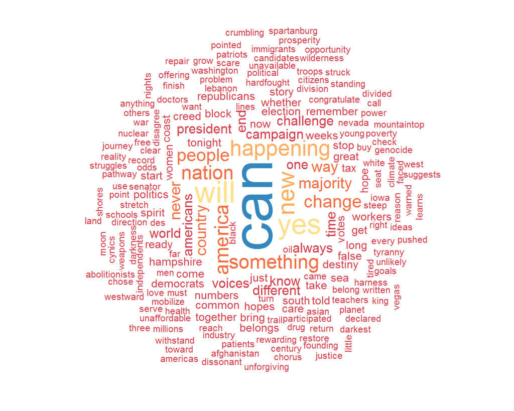

### Inaugural Address - Barack Obama

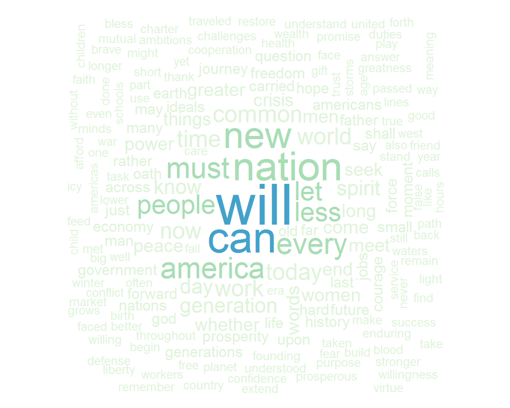

# The_Struggle_for_Human_Rights

### The Struggle for Human Rights (1948)

**ELEANOR ROOSEVELT (1884-1962)** - [Biography](https://www.whitehouse.gov/about-the-white-house/first-ladies/anna-eleanor-roosevelt/)

U.S. First Lady, Diplomat (1884-1962)

Longest-serving First Lady during her husband President Franklin D. Roosevelt’s four terms in office (1933-1945).

Eleanor Roosevelt delivered a speech in Paris (September 28, 1948) entitled “The Struggle for Human Rights,” to persuade United Nations member states to vote for the Universal Declaration of Human Rights.

**Universal Declaration of Human Rights** - [Link](http://www.un.org/en/universal-declaration-human-rights/)

The Universal Declaration of Human Rights (UDHR) was proclaimed by the United Nations General Assembly in Paris on 10 December 1948.

A historic document that states the basic rights and freedoms all human beings are entitled to. The Declaration consists of an introduction and 30 Articles.

For full text - [link](https://www.ohchr.org/EN/UDHR/Documents/UDHR_Translations/eng.pdf)

### The Struggle for Human Rights (1948)

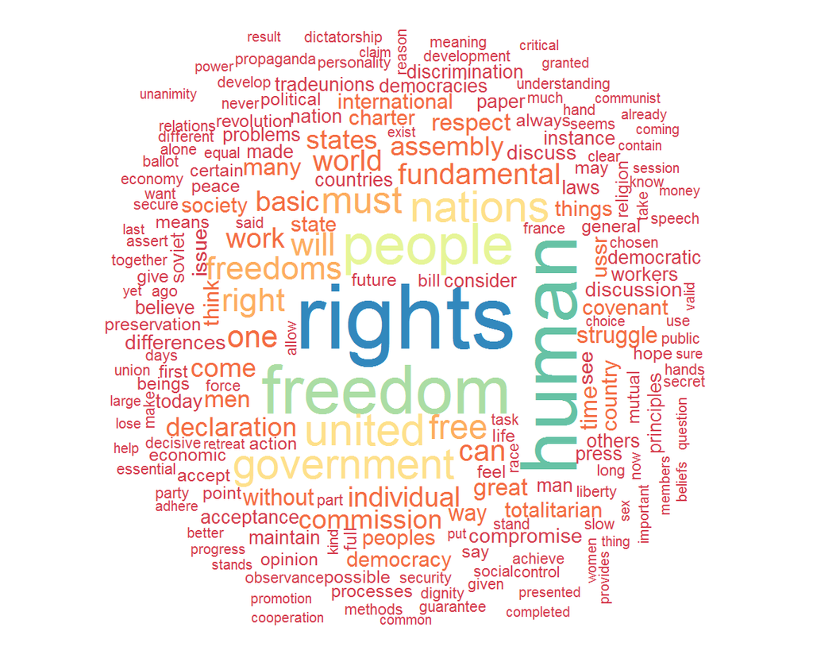

**R Packages used**

- flexdashboard
- tm
- SnowballC
- wordcloud
- RColorBrewer

**Code, questions and feedback**

The code for this article is publish in my [github account](https://github.com/JuanmaMN).

For [RPubs link](http://rpubs.com/Juanma7/440421). Resolution is not great.

Please feel free to reach out for any question or feedback.